# Moderated Mediation by lavaan

Akihito Kamata

March 14, 2020

## 0. Setups

Load required packages.

```r
library(tidyverse)
library(lavaan)
library(psych)
```

## 1. Introduction

### Data

This example is example 2.25 in Muthen, Muthen, & Asparouhov (p.108, 2016), which was originally from data from an automobile parts work team study by Kellam et al. (2008).

The model to be analyzed is as follows:

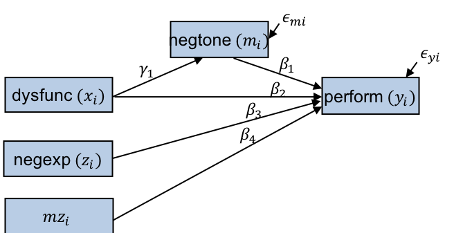

### Moderated Mediation

For this model, the mediation effect of $x_i$ on $y_i$ through the mediator $m_i$ depends on the value of the covariate $z_i$ as $(\beta_1\gamma_1 + \beta_4\gamma_1z_i)(x_1-x_0)$. Here, $x_1-x_0$ can be the standard deviation of variable $x$. This way, the mediation effect is scaled *per* standard deviation. Note that the formula for the moderated mediation depends on the type of the model. This particular example is characterized as Model 14 in Hays (2018).

### Read Data

Read and prepare data. Also, run descriptive statistics.

```r
teams <- read.table("Data/teams.txt")
colnames(teams) <- c("dysfunc","negtone","negexp","perform")
teams$mz <- teams$negtone * teams$negexp
teams %>% describe(fast=T)
```

|  | vars | n | mean | sd | min | max | range | se |
| --- | --- | --- | --- | --- | --- | --- | --- | --- |
| dysfunc | 1 | 60 | 0.03 | 0.37 | -0.50 | 1.16 | 1.66 | 0.05 |
| negtone | 2 | 60 | 0.05 | 0.53 | -1.01 | 1.95 | 2.96 | 0.07 |
| negexp | 3 | 60 | -0.01 | 0.54 | -1.16 | 0.93 | 2.09 | 0.07 |
| perform | 4 | 60 | -0.03 | 0.52 | -1.23 | 1.12 | 2.35 | 0.07 |
| mz | 5 | 60 | 0.02 | 0.28 | -0.80 | 1.17 | 1.96 | 0.04 |

### Specifications for lavaan

```
ex2.25.inp <- '
perform ~ b1*negtone + dysfunc + negexp + b4*mz
negtone ~ g1*dysfunc
med1 := (b1*g1 + b4*g1*(-.4))*.3688
med2 := (b1*g1 + b4*g1*(-.3))*.3688
med3 := (b1*g1 + b4*g1*(-.2))*.3688
med4 := (b1*g1 + b4*g1*(-.1))*.3688
med5 := (b1*g1 + b4*g1*(0))*.3688
med6 := (b1*g1 + b4*g1*(.1))*.3688
med7 := (b1*g1 + b4*g1*(.2))*.3688
med8 := (b1*g1 + b4*g1*(.3))*.3688
med9 := (b1*g1 + b4*g1*(.4))*.3688
med10 := (b1*g1 + b4*g1*(.5))*.3688
med11 := (b1*g1 + b4*g1*(.6))*.3688
'
```

However, this will become quite labor intensive, as we wish to increase the number of evaluation points. To overcome this, we can code in R to generate above model specifications. This way, we can easily specify many evaluation points with minimal effort. Note that we specify the lowest value (`from` = ), highest value (`to` = ) and increment (`by` = ) in the `seq` function below.

```r
eval.pts <- seq(from = -.4, to = .6, by = .1)

main.part <- c(
'perform ~ b1*negtone + dysfunc + negexp + b4*mz',
'negtone ~ g1*dysfunc')
med.part <-
  capture.output(
    for (i in 1:length(eval.pts)){
      cat('med', i, ':= (b1*g1 + b4*g1*(', eval.pts[i], '))*.3688',
          sep='', fill=T)
      })
ex2.25.inp <- c(main.part, med.part) %>% paste0(collapse = ' \n ')
```

Run the model with 1,000 bootstrap iterations.

```r
ex2.25.out <- sem(ex2.25.inp, data=teams, se="boot", bootstrap=1000)
```

### View a summary output

As you can see, there are multiple “defined parameters”, which are mediation effects at different evaluation points.

```r
summary(ex2.25.out)
```

```
lavaan 0.6-3 ended normally after 19 iterations

  Optimization method                           NLMINB
  Number of free parameters                          7

  Number of observations                            60

  Estimator                                         ML
  Model Fit Test Statistic                       6.425
  Degrees of freedom                                 2
  P-value (Chi-square)                           0.040

Parameter Estimates:

  Standard Errors                            Bootstrap
  Number of requested bootstrap draws             1000
  Number of successful bootstrap draws            1000

Regressions:
                   Estimate  Std.Err  z-value  P(>|z|)
  perform ~
    negtone   (b1)   -0.436    0.129   -3.370    0.001
    dysfunc           0.366    0.199    1.840    0.066
    negexp           -0.019    0.104   -0.184    0.854
    mz        (b4)   -0.517    0.242   -2.133    0.033
  negtone ~
    dysfunc   (g1)    0.620    0.222    2.796    0.005

Variances:
                   Estimate  Std.Err  z-value  P(>|z|)
   .perform           0.185    0.032    5.737    0.000
   .negtone           0.219    0.052    4.184    0.000

Defined Parameters:
                   Estimate  Std.Err  z-value  P(>|z|)
    med1             -0.052    0.048   -1.080    0.280
    med2             -0.064    0.045   -1.417    0.156
    med3             -0.076    0.043   -1.768    0.077
    med4             -0.088    0.042   -2.107    0.035
    med5             -0.100    0.041   -2.402    0.016
    med6             -0.111    0.042   -2.629    0.009
    med7             -0.123    0.044   -2.779    0.005
    med8             -0.135    0.047   -2.859    0.004
    med9             -0.147    0.051   -2.886    0.004
    med10            -0.159    0.055   -2.878    0.004
    med11            -0.170    0.060   -2.847    0.004
```

### Extract parameter estimates

The table including lower and upper bounds of Bootstrap confidence intervals.

```r
parameterEstimates(ex2.25.out)
```

|  | lhs | op | rhs | label | est | se | z | pvalue | ci.lower | ci.upper |
| --- | --- | --- | --- | --- | --- | --- | --- | --- | --- | --- |
| 1 | perform | ~ | negtone | b1 | -0.436 | 0.129 | -3.370 | 0.001 | -0.647 | -0.135 |
| 2 | perform | ~ | dysfunc |  | 0.366 | 0.199 | 1.840 | 0.066 | -0.109 | 0.674 |
| 3 | perform | ~ | negexp |  | -0.019 | 0.104 | -0.184 | 0.854 | -0.240 | 0.170 |
| 4 | perform | ~ | mz | b4 | -0.517 | 0.242 | -2.133 | 0.033 | -1.087 | -0.128 |
| 5 | negtone | ~ | dysfunc | g1 | 0.620 | 0.222 | 2.796 | 0.005 | 0.240 | 1.127 |
| 6 | perform | ~~ | perform |  | 0.185 | 0.032 | 5.737 | 0.000 | 0.109 | 0.231 |
| 7 | negtone | ~~ | negtone |  | 0.219 | 0.052 | 4.184 | 0.000 | 0.116 | 0.326 |
| 8 | dysfunc | ~~ | dysfunc |  | 0.136 | 0.000 | NA | NA | 0.136 | 0.136 |
| 9 | dysfunc | ~~ | negexp |  | -0.001 | 0.000 | NA | NA | -0.001 | -0.001 |
| 10 | dysfunc | ~~ | mz |  | -0.004 | 0.000 | NA | NA | -0.004 | -0.004 |

[output cut: 14 more lines]

Now, extract only the point estimates and lower & upper bounds of CI for mediation effects. Since mediation effects have lavaan operator `:=`, we will first filter the above parameter estimate data table by `filter(op == ":=")`. Then, select only `est` (point estimates of mediation effects), `ci.lower` (lower bound of 95% CI) and `ci.upper` (upper bound of 95% CI). Store the extracted moderated mediation results as `modmed.out`.

```r
modmed.out <-
  parameterEstimates(ex2.25.out) %>%
  filter(op == ":=") %>%
  select(est, ci.lower, ci.upper) %>%
  cbind(eval.pts, .)
modmed.out
```

| eval.pts | est | ci.lower | ci.upper |
| --- | --- | --- | --- |
| -0.4 | -0.05233271 | -0.1404794 | 0.06538125 |
| -0.3 | -0.06414876 | -0.1526367 | 0.03734570 |
| -0.2 | -0.07596481 | -0.1593858 | 0.01123009 |
| -0.1 | -0.08778086 | -0.1738071 | -0.01030290 |
| 0.0 | -0.09959690 | -0.1914551 | -0.02440247 |
| 0.1 | -0.11141295 | -0.2060413 | -0.03478239 |
| 0.2 | -0.12322900 | -0.2169129 | -0.04239084 |
| 0.3 | -0.13504505 | -0.2363442 | -0.04735168 |
| 0.4 | -0.14686109 | -0.2510976 | -0.05184714 |
| 0.5 | -0.15867714 | -0.2666518 | -0.05512400 |

[output cut: 1 more lines]

Inspection of the above table indicates that the 95% CI did not captures 0, when the evaluation point was -0.1 or higher. In other words, the mediation effect was statistically significant at $\alpha=.05$ level, when the value of the covariate `negexp` was -0.1 or larger.

### Plotting Moderated Mediation

We can plot the results. This requires to reshape the result data before using `ggplot`.

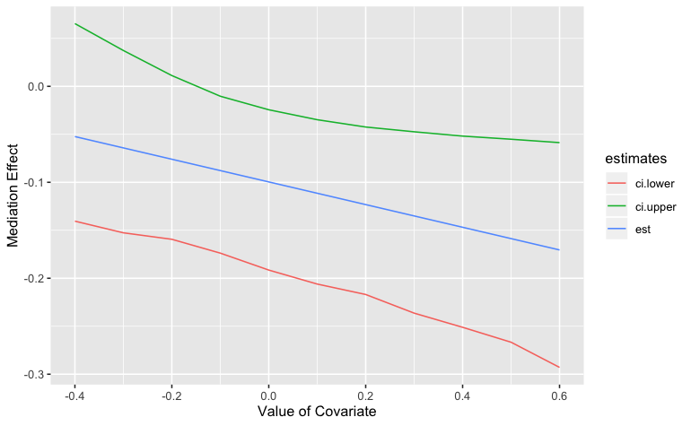

```r
modmed.out %>%
  gather("estimates","values", 2:4) %>%
  ggplot(aes(x=eval.pts, y=values, colour=estimates)) +
  geom_line() + ylab("Mediation Effect") + xlab("Value of Covariate")
```

As we can see, the upper bound of the 95% CI intersects with 0, somewhere between -0.2 and -0.1, which means that the region of statistical significance is when the value of covariate was about -0.15 or larger. If we need to derive a more accurate threshold of statistical significance, we need to run the analysis with evaluation points with smaller increment, such as 0.01.